# Group 20

Sean Pedersen, Cole Smith, Brooke Ealey, Zhehui Yuan

4/21/2020

## Project Goal

We will try to use the [restaurant data](https://www.kaggle.com/c/recruit-restaurant-visitor-forecasting/overview) from Kaggle to predict the future volume of visitor for restaurants in Japan. We build a time series model by using *cluster* and *prophet package* to reach RMSE at 0.76

## Packge install

We install necessary packages for this project first

```r
installIfAbsentAndLoad <- function(neededVector) {
  for(thispackage in neededVector) {
    if( ! require(thispackage, character.only = T) )
    { install.packages(thispackage)}
    require(thispackage, character.only = T)
  }
}

needed <- c('dplyr', 'ggplot2', 'tidyverse', 'cluster','factoextra', 'prophet', 'magrittr', 'taRifx', 'Metrics', 'e1071')
installIfAbsentAndLoad(needed)
```

## load data

```r
df_air <- read.csv('air_visit_data.csv')
df_air_store <- read.csv('air_store_info.csv')
```

## EDA

plots total restaurant visitors accross all stores in training data

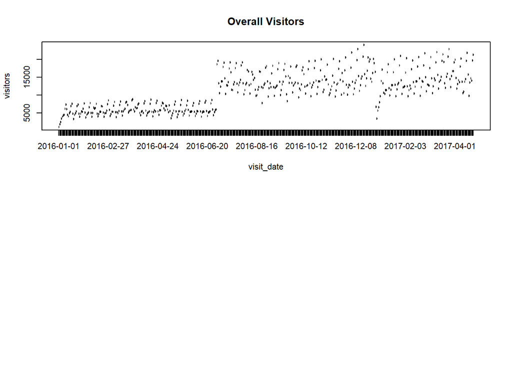

```r
par(mfrow=c(2,1), cex=0.7)
df_air %>%
  group_by(visit_date) %>%
  summarize(visitors = sum(visitors)) %>%
  plot(type='l', main='Overall Visitors')
```

Merge data

```r
#annual visitors by store_id
total_visits<- df_air %>% group_by(air_store_id) %>% summarize(visitors = sum(visitors))

####combines store visit info with store location info into one dataframe
air_merged <- total_visits %>%
  dplyr::left_join(df_air_store, by='air_store_id', how='left')
head(air_merged)
```

```
## # A tibble: 6 x 6
##   air_store_id   visitors air_genre_name air_area_name        latitude longitude
##   <fct>             <int> <fct>          <fct>                   <dbl>     <dbl>
## 1 air_00a91d42b~     6051 Italian/French "TÅ\u008dkyÅ\u008d-~     35.7      140.
## 2 air_0164b9927~     1378 Italian/French "TÅ\u008dkyÅ\u008d-~     35.7      140.
## 3 air_0241aa396~     3919 Izakaya        "TÅ\u008dkyÅ\u008d-~     35.7      140.
## 4 air_032869619~      921 Dining bar     "ÅŒsaka-fu ÅŒsaka-s~     34.7      136.
## 5 air_034a3d5b4~     3722 Cafe/Sweets    ÅŒsaka-fu ÅŒsaka-sh~     34.7      135.
## 6 air_036d4f1ee~     6310 Cafe/Sweets    "HyÅ\u008dgo-ken Ta~     34.8      135.
```

```r
air_merged2<- air_merged[, c(1,2)]
head(air_merged2)
```

```
## # A tibble: 6 x 2
##   air_store_id         visitors
##   <fct>                   <int>
## 1 air_00a91d42b08b08d9     6051
## 2 air_0164b9927d20bcc3     1378
## 3 air_0241aa3964b7f861     3919
## 4 air_0328696196e46f18      921
## 5 air_034a3d5b40d5b1b1     3722
## 6 air_036d4f1ee7285390     6310
```

## Modeling- cluster analysis

We use Gower’s method by creating **5** clusters or **2** clusters after we checked the plot. We compare these two choice of cluster number, and make final decisions. But before we run our model, will fisrt run the author’s model from kaggle first in order to do comparison

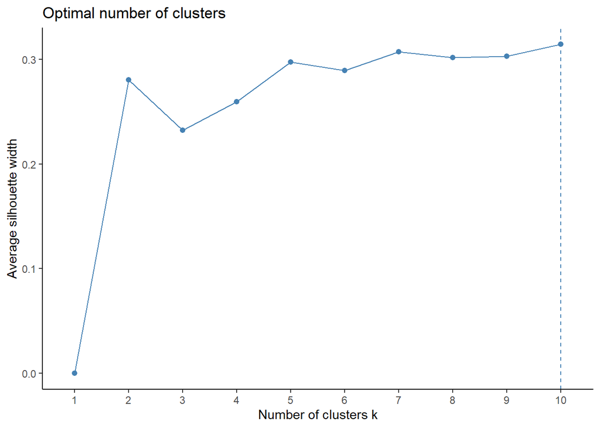

```r
#creates cluster of our data with num of visitors included
FundDist <- as.matrix(daisy(air_merged, metric = 'gower', stand = TRUE))

#tells us the optimal number of clusters to use
fviz_nbclust(FundDist, pam, method = "silhouette")+
  theme_classic()
```

```r
#the output above indicates that 10 is the optimal number of clusters. We could also use 7 or even 5
# After running several simulations we found 5 clusters achieves the best results.
pam.res <- pam(FundDist, 5) # put the number you select in here


air_merged <- cbind(air_merged, cluster = pam.res$cluster) # add the cluster numbers to  a new column in the data set

# 3 lines below create dataframe containing all store daily visitors and cluster IDs
air_merged<- air_merged[, -2] #drops annual visitors
all_store_info<- df_air %>%
  dplyr::left_join(air_merged, by='air_store_id', how='left')

all_store_info$visit_date <- as.Date(all_store_info$visit_date, origin = '1899-12-30') #format date for prophet funciton
```

#### Author’s method

Blocks of code below contains function that runs 42 day forecast based on avg demand per cluster. This is an improvement upon Konrad Banachewicz’s score (kaggle Notebook author) because our forecast is based off of the average demand of each cluster rather than an average of the enture data set. This is essential because we only want to base our forecasts off of restaurants of similar revenue structure. It wouldn’t make sense to forecast the performance of a 5 star restaurant based on the demand of the local coffee shop down the street. In short, we want to compare apples to apples.

```r
group_mean<- aggregate(visitors~visit_date, data = all_store_info, FUN = mean)
train<- group_mean %>% filter(visit_date < '2017-03-12')
names(train)<- c('ds', 'y')#need to rename cols for prohpet packacge
train$y<- log(train$y) #log our data for more accurate results
m<- prophet(train)
```

```
## Disabling yearly seasonality. Run prophet with yearly.seasonality=TRUE to override this.
```

```
## Disabling daily seasonality. Run prophet with daily.seasonality=TRUE to override this.
```

```r
future<- make_future_dataframe(m, periods = 42)
forecast<- predict(m, future)
results<- forecast %>% filter(ds >= '2017-03-11')
results<- results[, c(1, 16)]
kaggle_forecast<- function(i){
  store1<- all_store_info[all_store_info$air_store_id == i,]
  group_result<- store1 %>% filter(visit_date >= '2017-03-12')
  group_result$visit_date<- as.Date(group_result$visit_date, origin = '1899-12-30')
  group_result<- group_result[, c(2,3)]
  names(results)<- c('visit_date', 'y')
  results$visit_date<- as.Date(results$visit_date, origin = '1899-12-30')
  store_forecast<-group_result %>%
    dplyr::left_join(results, by = 'visit_date', how='left')
  output <-rmse(log(store_forecast$visitors), store_forecast$y)
  return(output)
}

store_names<- unique(all_store_info$air_store_id)
kaggle_RMSE<- c()
for (i in store_names){
  temp_store_rmse<-kaggle_forecast(i)
  kaggle_RMSE<- c(kaggle_RMSE, temp_store_rmse)
}
kaggle_RMSE<- data.frame(kaggle_RMSE) #one store doesn't cover the timeline so it was removed
kaggle_RMSE<- na.omit(kaggle_RMSE)
kaggle_RMSE<-mean(kaggle_RMSE$kaggle_RMSE)
kaggle_RMSE
```

```
## [1] 0.8942447
```

### Gower’s 5 cluster method

```r
cluster_1<- all_store_info[all_store_info$cluster == 1,]
cluster_1_stores<- unique(cluster_1$air_store_id)
cluster_2<- all_store_info[all_store_info$cluster == 2,]
cluster_2_stores<- unique(cluster_2$air_store_id)
cluster_3<- all_store_info[all_store_info$cluster == 3,]
cluster_3_stores<- unique(cluster_3$air_store_id)
cluster_4<- all_store_info[all_store_info$cluster == 4,]
cluster_4_stores<- unique(cluster_4$air_store_id)
cluster_5<- all_store_info[all_store_info$cluster == 5,]
cluster_5_stores<- unique(cluster_5$air_store_id)
```

##### cluster 1 forecast

```r
group_mean<- aggregate(visitors~visit_date, data = cluster_1, FUN = mean)
train<- group_mean %>% filter(visit_date < '2017-03-12')
names(train)<- c('ds', 'y')#need to rename cols for prohpet packacge
train$y<- log(train$y) #log our data for more accurate results
m<- prophet(train)
```

```
## Disabling yearly seasonality. Run prophet with yearly.seasonality=TRUE to override this.
```

```
## Disabling daily seasonality. Run prophet with daily.seasonality=TRUE to override this.
```

```r
future<- make_future_dataframe(m, periods = 42)
forecast<- predict(m, future)
results<- forecast %>% filter(ds >= '2017-03-11')
results<- results[, c(1, 16)]
cluster_1_forecast<- function(i){
  store1<- all_store_info[all_store_info$air_store_id == i,]
  group_result<- store1 %>% filter(visit_date >= '2017-03-12')
  group_result$visit_date<- as.Date(group_result$visit_date, origin = '1899-12-30')
  group_result<- group_result[, c(2,3)]
  names(results)<- c('visit_date', 'y')
  results$visit_date<- as.Date(results$visit_date, origin = '1899-12-30')
  store_forecast<-group_result %>%
    dplyr::left_join(results, by = 'visit_date', how='left')
  output <-rmse(log(store_forecast$visitors), store_forecast$y)
  return(output)
}
cluster_1_RMSE<- c()
for (i in cluster_1_stores){
  temp_store_rmse<-cluster_1_forecast(i)
  cluster_1_RMSE<- c(cluster_1_RMSE, temp_store_rmse)
}
#(cluster_1_RMSE<-mean(cluster_1_RMSE))
cluster_1_RMSE<- data.frame(cluster_1_RMSE) #one store doesn't cover the timeline so it was removed
cluster_1_RMSE<- na.omit(cluster_1_RMSE)
cluster_1_RMSE<-mean(cluster_1_RMSE$cluster_1_RMSE)
cluster_1_RMSE
```

```
## [1] 0.9167772
```

##### cluster 2 forecast

```r
group_mean<- aggregate(visitors~visit_date, data = cluster_2, FUN = mean)
train<- group_mean %>% filter(visit_date < '2017-03-12')
names(train)<- c('ds', 'y')#need to rename cols for prohpet packacge
train$y<- log(train$y) #log our data for more accurate results
m<- prophet(train)
```

```
## Disabling yearly seasonality. Run prophet with yearly.seasonality=TRUE to override this.
```

```
## Disabling daily seasonality. Run prophet with daily.seasonality=TRUE to override this.
```

```r
future<- make_future_dataframe(m, periods = 42)
forecast<- predict(m, future)
results<- forecast %>% filter(ds >= '2017-03-11')
results<- results[, c(1, 16)]
cluster_2_forecast<- function(i){
  store1<- all_store_info[all_store_info$air_store_id == i,]
  group_result<- store1 %>% filter(visit_date >= '2017-03-12')
  group_result$visit_date<- as.Date(group_result$visit_date, origin = '1899-12-30')
  group_result<- group_result[, c(2,3)]
  names(results)<- c('visit_date', 'y')
  results$visit_date<- as.Date(results$visit_date, origin = '1899-12-30')
  store_forecast<-group_result %>%
    dplyr::left_join(results, by = 'visit_date', how='left')
  output <-rmse(log(store_forecast$visitors), store_forecast$y)
  return(output)
}
cluster_2_RMSE<- c()
for (i in cluster_2_stores){
  temp2_store_rmse<-cluster_2_forecast(i)
  cluster_2_RMSE<- c(cluster_2_RMSE, temp2_store_rmse)
}
cluster_2_RMSE<- data.frame(cluster_2_RMSE) #one store doesn't cover the timeline so it was removed
cluster_2_RMSE<- na.omit(cluster_2_RMSE)
cluster_2_RMSE<-mean(cluster_2_RMSE$cluster_2_RMSE)
cluster_2_RMSE
```

```
## [1] 0.8426359
```

##### cluster 3 forecast

```r
group_mean<- aggregate(visitors~visit_date, data = cluster_3, FUN = mean)
train<- group_mean %>% filter(visit_date < '2017-03-12')
names(train)<- c('ds', 'y')#need to rename cols for prohpet packacge
train$y<- log(train$y) #log our data for more accurate results
m<- prophet(train)
```

```
## Disabling yearly seasonality. Run prophet with yearly.seasonality=TRUE to override this.
```

```
## Disabling daily seasonality. Run prophet with daily.seasonality=TRUE to override this.
```

```r
future<- make_future_dataframe(m, periods = 42)
forecast<- predict(m, future)
results<- forecast %>% filter(ds >= '2017-03-11')
results<- results[, c(1, 16)]
cluster_3_forecast<- function(i){
  store1<- all_store_info[all_store_info$air_store_id == i,]
  group_result<- store1 %>% filter(visit_date >= '2017-03-12')
  group_result$visit_date<- as.Date(group_result$visit_date, origin = '1899-12-30')
  group_result<- group_result[, c(2,3)]
  names(results)<- c('visit_date', 'y')
  results$visit_date<- as.Date(results$visit_date, origin = '1899-12-30')
  store_forecast<-group_result %>%
    dplyr::left_join(results, by = 'visit_date', how='left')
  output <-rmse(log(store_forecast$visitors), store_forecast$y)
  return(output)
}
cluster_3_RMSE<- c()
for (i in cluster_3_stores){
  temp_store_rmse<-cluster_3_forecast(i)
  cluster_3_RMSE<- c(cluster_3_RMSE, temp_store_rmse)
}

cluster_3_RMSE<- mean(cluster_3_RMSE)

cluster_3_RMSE
```

```
## [1] 0.7873945
```

##### cluster 4 forecast

```r
group_mean<- aggregate(visitors~visit_date, data = cluster_4, FUN = mean)
train<- group_mean %>% filter(visit_date < '2017-03-12')
names(train)<- c('ds', 'y')#need to rename cols for prohpet packacge
train$y<- log(train$y) #log our data for more accurate results
m<- prophet(train)
```

```
## Disabling yearly seasonality. Run prophet with yearly.seasonality=TRUE to override this.
```

```
## Disabling daily seasonality. Run prophet with daily.seasonality=TRUE to override this.
```

```r
future<- make_future_dataframe(m, periods = 42)
forecast<- predict(m, future)
results<- forecast %>% filter(ds >= '2017-03-11')
results<- results[, c(1, 16)]
cluster_4_forecast<- function(i){
  store1<- all_store_info[all_store_info$air_store_id == i,]
  group_result<- store1 %>% filter(visit_date >= '2017-03-12')
  group_result$visit_date<- as.Date(group_result$visit_date, origin = '1899-12-30')
  group_result<- group_result[, c(2,3)]
  names(results)<- c('visit_date', 'y')
  results$visit_date<- as.Date(results$visit_date, origin = '1899-12-30')
  store_forecast<-group_result %>%
    dplyr::left_join(results, by = 'visit_date', how='left')
  output <-rmse(log(store_forecast$visitors), store_forecast$y)
  return(output)
}
cluster_4_RMSE<- c()
for (i in cluster_4_stores){
  temp_store_rmse<-cluster_4_forecast(i)
  cluster_4_RMSE<- c(cluster_4_RMSE, temp_store_rmse)
}
#cluster_4_RMSE<-mean(cluster_4_RMSE)
cluster_4_RMSE<- data.frame(cluster_4_RMSE) #one store doesn't cover the timeline so it was removed
cluster_4_RMSE<- na.omit(cluster_4_RMSE)
cluster_4_RMSE<-mean(cluster_4_RMSE$cluster_4_RMSE)
cluster_4_RMSE
```

```
## [1] 0.9241514
```

##### cluster 5 forecast

```r
group_mean<- aggregate(visitors~visit_date, data = cluster_5, FUN = mean)
train<- group_mean %>% filter(visit_date < '2017-03-12')
names(train)<- c('ds', 'y')#need to rename cols for prohpet packacge
train$y<- log(train$y) #log our data for more accurate results
m<- prophet(train)
```

```
## Disabling yearly seasonality. Run prophet with yearly.seasonality=TRUE to override this.
```

```
## Disabling daily seasonality. Run prophet with daily.seasonality=TRUE to override this.
```

```r
future<- make_future_dataframe(m, periods = 42)
forecast<- predict(m, future)
results<- forecast %>% filter(ds >= '2017-03-11')
results<- results[, c(1, 16)]
cluster_5_forecast<- function(i){
  store1<- all_store_info[all_store_info$air_store_id == i,]
  group_result<- store1 %>% filter(visit_date >= '2017-03-12')
  group_result$visit_date<- as.Date(group_result$visit_date, origin = '1899-12-30')
  group_result<- group_result[, c(2,3)]
  names(results)<- c('visit_date', 'y')
  results$visit_date<- as.Date(results$visit_date, origin = '1899-12-30')
  store_forecast<-group_result %>%
    dplyr::left_join(results, by = 'visit_date', how='left')
  output <-rmse(log(store_forecast$visitors), store_forecast$y)
  return(output)
}
cluster_5_RMSE<- c()
for (i in cluster_5_stores){
  temp_store_rmse<-cluster_5_forecast(i)
  cluster_5_RMSE<- c(cluster_5_RMSE, temp_store_rmse)
}
cluster_5_RMSE<- data.frame(cluster_5_RMSE) #one store doesn't cover the timeline so it was removed
cluster_5_RMSE<- na.omit(cluster_5_RMSE)
cluster_5_RMSE<-mean(cluster_5_RMSE$cluster_5_RMSE)
cluster_5_RMSE
```

```
## [1] 0.9326878
```

##### RMSE 5 Cluster Output

```r
(five_cluster_RMSE<- sum(cluster_2_RMSE, cluster_1_RMSE, cluster_3_RMSE, cluster_4_RMSE, cluster_5_RMSE)/5)
```

```
## [1] 0.8807293
```

```r
#actual RMSE
(five_cluster_customer_variance<- sqrt(exp(five_cluster_RMSE)))
```

```
## [1] 1.553274
```

```r
#reverses the log and then takes the square root in order to
# make our results more interpretable
#On average our forecast will over/under estimate daily customers by 1.5
```

### Gowers Method with 2 Clusters

```r
#run same script as above except we create clusters using only aggregated annual customers.
# We used this approach in order to compare companies based exclusively on customer size
air_merged <- total_visits %>%
  dplyr::left_join(df_air_store, by='air_store_id', how='left')

air_merged2<- air_merged[, c(1,2)] #grabs store name and total customers
```

### Gowers 2 cluster method

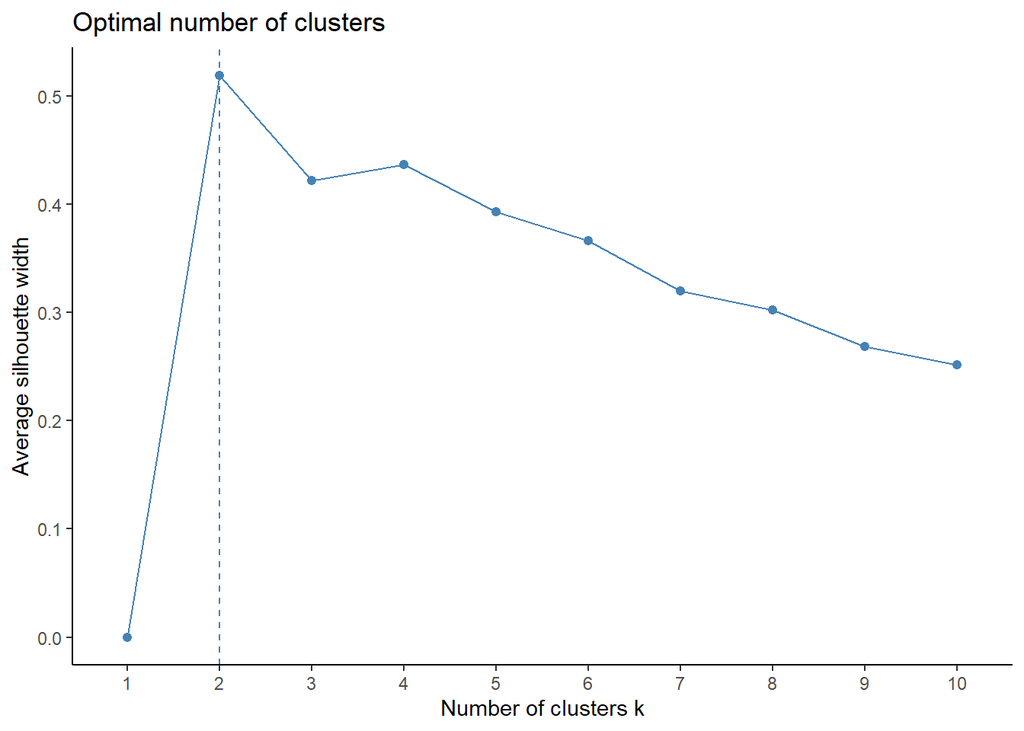

```r
#creates cluster of our data with num of visitors included
FundDist2 <- as.matrix(daisy(air_merged2, metric = 'gower', stand = TRUE))

#tells us the optimal number of clusters to use
fviz_nbclust(FundDist2, pam, method = "silhouette")+
  theme_classic()
```

```r
pam.res <- pam(FundDist2, 2) # put the number you select in here

air_merged <- cbind(air_merged, cluster = pam.res$cluster) # add the cluster numbers to  a new column in the data set

# 3 lines below create dataframe containing all store daily visitors and cluster IDs
air_merged<- air_merged[, -2] #drops annual visitors
all_store_info<- df_air %>%
  dplyr::left_join(air_merged, by='air_store_id', how='left')

all_store_info$visit_date <- as.Date(all_store_info$visit_date, origin = '1899-12-30') #format date for prophet funciton


cluster_1<- all_store_info[all_store_info$cluster == 1,]
cluster_1_stores<- unique(cluster_1$air_store_id)
cluster_2<- all_store_info[all_store_info$cluster == 2,]
cluster_2_stores<- unique(cluster_2$air_store_id)
```

##### cluster 1 forecast 2c

```r
group_mean<- aggregate(visitors~visit_date, data = cluster_1, FUN = mean)
train<- group_mean %>% filter(visit_date < '2017-03-12')
names(train)<- c('ds', 'y')#need to rename cols for prohpet packacge
train$y<- log(train$y) #log our data for more accurate results
m<- prophet(train)
```

```
## Disabling yearly seasonality. Run prophet with yearly.seasonality=TRUE to override this.
```

```
## Disabling daily seasonality. Run prophet with daily.seasonality=TRUE to override this.
```

```r
future<- make_future_dataframe(m, periods = 42)
forecast<- predict(m, future)
results<- forecast %>% filter(ds >= '2017-03-11')
results<- results[, c(1, 16)]
cluster_1_forecast<- function(i){
  store1<- all_store_info[all_store_info$air_store_id == i,]
  group_result<- store1 %>% filter(visit_date >= '2017-03-12')
  group_result$visit_date<- as.Date(group_result$visit_date, origin = '1899-12-30')
  group_result<- group_result[, c(2,3)]
  names(results)<- c('visit_date', 'y')
  results$visit_date<- as.Date(results$visit_date, origin = '1899-12-30')
  store_forecast<-group_result %>%
    dplyr::left_join(results, by = 'visit_date', how='left')
  output <-rmse(log(store_forecast$visitors), store_forecast$y)
  return(output)
}
cluster_1_RMSE_c2<- c()
for (i in cluster_1_stores){
  temp_store_rmse<-cluster_1_forecast(i)
  cluster_1_RMSE_c2<- c(cluster_1_RMSE_c2, temp_store_rmse)
}
cluster_1_RMSE_c2<- data.frame(cluster_1_RMSE_c2) #one store doesn't cover the timeline so it was removed
cluster_1_RMSE_c2<- na.omit(cluster_1_RMSE_c2)
cluster_1_RMSE_c2<-mean(cluster_1_RMSE_c2$cluster_1_RMSE_c2)
cluster_1_RMSE_c2
```

```
## [1] 0.8721628
```

##### cluster 2 forecast 2c

```r
group_mean<- aggregate(visitors~visit_date, data = cluster_2, FUN = mean)
train<- group_mean %>% filter(visit_date < '2017-03-12')
names(train)<- c('ds', 'y')#need to rename cols for prohpet packacge
train$y<- log(train$y) #log our data for more accurate results
m<- prophet(train)
```

```
## Disabling yearly seasonality. Run prophet with yearly.seasonality=TRUE to override this.
```

```
## Disabling daily seasonality. Run prophet with daily.seasonality=TRUE to override this.
```

```r
future<- make_future_dataframe(m, periods = 42)
forecast<- predict(m, future)
results<- forecast %>% filter(ds >= '2017-03-11')
results<- results[, c(1, 16)]

cluster_2_forecast<- function(i){
  store1<- all_store_info[all_store_info$air_store_id == i,]
  group_result<- store1 %>% filter(visit_date >= '2017-03-12')
  group_result$visit_date<- as.Date(group_result$visit_date, origin = '1899-12-30')
  group_result<- group_result[, c(2,3)]
  names(results)<- c('visit_date', 'y')
  results$visit_date<- as.Date(results$visit_date, origin = '1899-12-30')
  store_forecast<-group_result %>%
    dplyr::left_join(results, by = 'visit_date', how='left')
  output <-rmse(log(store_forecast$visitors), store_forecast$y)
  return(output)
}
cluster_2_RMSE_c2<- c()
for (i in cluster_2_stores){
  temp2_store_rmse<-cluster_2_forecast(i)
  cluster_2_RMSE_c2<- c(cluster_2_RMSE_c2, temp2_store_rmse)
}
cluster_2_RMSE_c2<- data.frame(cluster_2_RMSE_c2) #one store doesn't cover the timeline so it was removed
cluster_2_RMSE_c2<- na.omit(cluster_2_RMSE_c2)
cluster_2_RMSE_c2<-mean(cluster_2_RMSE_c2$cluster_2_RMSE_c2)
cluster_2_RMSE_c2
```

```
## [1] 0.6590068
```

###### RMSE 2 Cluster Output

```r
(two_cluster_RMSE<- sum(cluster_1_RMSE_c2, cluster_2_RMSE_c2)/2)
```

```
## [1] 0.7655848
```

```r
#actual RMSE

(two_cluster_customer_variance<- sqrt(exp(two_cluster_RMSE)))
```

```
## [1] 1.466374
```

```r
#On average our forecast will over/under estimate daily customers by 1.4
```

## Final Results

```r
kaggle_RMSE
```

```
## [1] 0.8942447
```

```r
two_cluster_RMSE
```

```
## [1] 0.7655848
```